# 1_analisis_exploratorio

#### 2.2.5 Variable *Age-range*

Atributo que divide en 5 franjas la edad de la persona involucrada en la actuación policial: menores de 10, entre 10 y 17 años, entre 18 y 24, entre 25 y 34 y mayores de 34. Se añade además un valor por defecto que se asigna a los valores perdidos.

```python
# Información básica de la variable
print('Número de valores diferentes:', len(pd.unique(london_data['Age-range'])))
print(london_data['Age-range'].value_counts(dropna=False))
```

```
Número de valores diferentes: 6
18-24       275199
25-34       170390
10-17       134862
over 34     124706
NaN          80386
under 10       178
Name: Age-range, dtype: int64
```

```python
# Se asigna un valor por defecto a los registros con valor desconocido y se homogeneiza el uso de
# mayúsculas/minúsculas en los textos
london_data['Age-range'] = london_data['Age-range'].fillna('Unknown')
london_data['Age-range'] = london_data['Age-range'].str.capitalize()

# Se marca la variable como categoría con orden entre sus elementos
age_range_type = CategoricalDtype(categories=['Under 10', '10-17', '18-24', '25-34', 'Over 34', 'Unknown'], ordered=True)
london_data['Age-range'] = london_data['Age-range'].astype(age_range_type)
```

Las personas con una franja de edad entre 18 y 24 años son las más paradas por la policía, aunque el porcentaje mayor de registros positivos se da en la franja de 25-34 años.

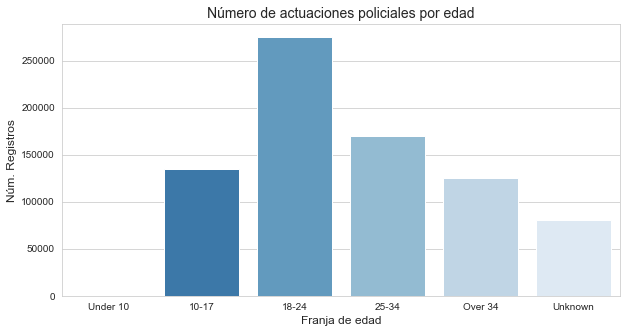

```python
# Gráfica con el número de actuaciones policiales por franja de edad
plt.figure(figsize=(10, 5))
sns.set_style('whitegrid')
sns.countplot(x='Age-range', data=london_data, palette='Blues_r')
plt.title('Número de actuaciones policiales por edad', fontsize=14)
plt.xlabel('Franja de edad', fontsize=12)
plt.ylabel('Núm. Registros', fontsize=12)
plt.show()
```

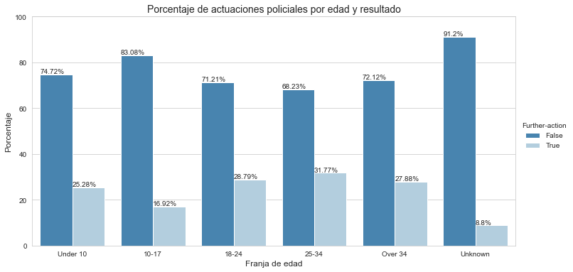

```python
# Porcentaje de registros por edad y resultado
percentage_plot(london_data, 'Age-range', 'Further-action',
                'Porcentaje de actuaciones policiales por edad y resultado',
                'Franja de edad').show()
```

En el mapa de calor que se muestra a continuación pueden observarse claramente las franjas de edad con mayor número de registros positivos por tipo de resultado.  
En concreto, los arrestos y las resoluciones comunitarias tienen una mayor prevalencia y se dan especialmente entre los 18 y 34 años, aunque las franjas inmediatamente inferior y superior también presentan bastantes casos. El concepto de sospechoso bajo arresto es también frecuente en la misma franja de edad. Le sigue el aviso de sanción por desorden (*penalty notice for disorder*) aunque está muy acotado a las franjas de 18-24 y 25-34.

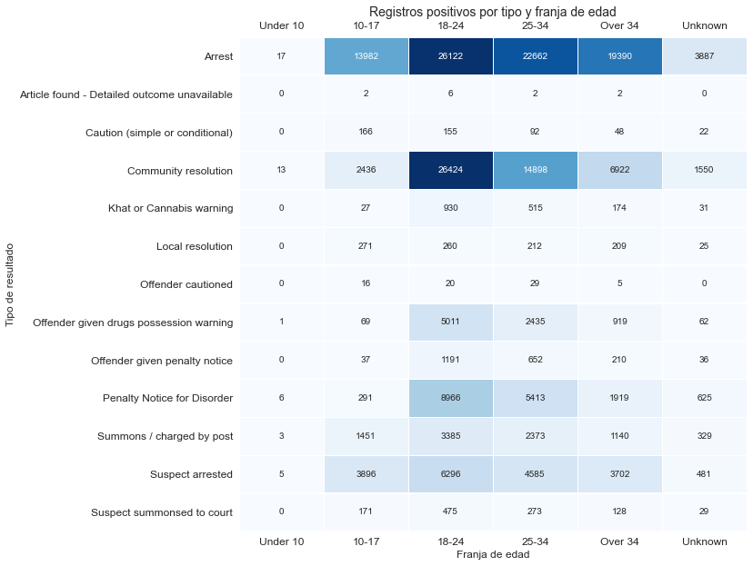

```python
# Se genera una tabla cruzada con el número de registros con resultado positivo por
# tipo y franja de edad
further_action_data = london_data[london_data['Further-action']].copy(deep=True)
cross_data = pd.crosstab(further_action_data['Outcome'],
                         further_action_data['Age-range'],
                         values=further_action_data['Outcome'],
                         aggfunc='count')

# Mapa de calor
plt.figure(figsize=(10, 10))
sns.heatmap(cross_data, annot=True, cmap="Blues", fmt=".0f", linewidths=.2, cbar=False)
plt.tick_params(labeltop=True, labelsize=12)
plt.title('Registros positivos por tipo y franja de edad', fontsize=14)
plt.xlabel('Franja de edad', fontsize=12)
plt.ylabel('Tipo de resultado', fontsize=12)
plt.show()
```

Se complementa el mapa de calor con una gráfica de barras donde se han eliminado los tipos de resultados menos comunes y donde no se muestra la franja de menos de 10 años por su escaso número de registros.

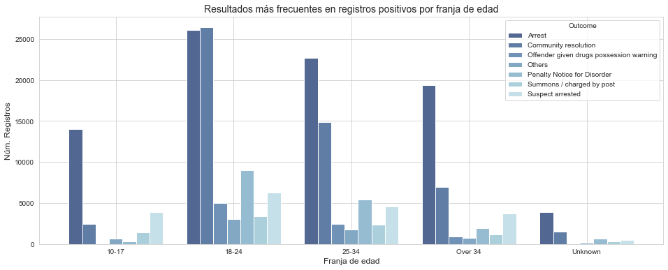

```python
# Se recogen los tipos de resultados menos frecuentes y se agrupan en una misma categoría
bottom_fa_list = further_action_data['Outcome'].value_counts().nsmallest(7).keys()
further_action_data['Outcome'] = further_action_data['Outcome'].apply(lambda x: 'Others' if x in bottom_fa_list else x)

# Se eliminan los registros correspondientes a la franja de edad de menos de 10 años, debido a su bajo número
further_action_data = further_action_data.drop(further_action_data[further_action_data['Age-range']=='Under 10'].index)
further_action_data['Age-range'] = further_action_data['Age-range'].cat.remove_unused_categories()

# Se dibuja una gráfica con los resultados más frecuentes por franja de edad
cross_data = pd.crosstab(further_action_data['Age-range'],
                         further_action_data['Outcome'],
                         values=further_action_data['Outcome'],
                         aggfunc='count')
cross_data.plot.bar(figsize=(16, 6), stacked=False, rot=0, width=0.8,
                    color=sns.cubehelix_palette(n_colors=7, start=0.05, rot=-.2, dark=.4, reverse=True))
plt.title('Resultados más frecuentes en registros positivos por franja de edad', fontsize=14)
plt.xlabel('Franja de edad', fontsize=12)
plt.ylabel('Núm. Registros', fontsize=12)
plt.show()
```

#### 2.2.6 Variable *Self-ethnicity*

Raza o etnia declarada por la persona afectada por la actuación policial. El número de posibles categorías es muy elevado y tiene valores repetidos con distinta codificación, por lo que se realiza una limpieza y homogeneización de valores.

```python
# Información básica de la variable
print('Número de valores diferentes:', len(pd.unique(london_data['Self-ethnicity'])))
print(london_data['Self-ethnicity'].value_counts(dropna=False))
```

```
Número de valores diferentes: 31
Other ethnic group - Not stated                                                         153305
White - English/Welsh/Scottish/Northern Irish/British                                   148104
Black/African/Caribbean/Black British - Any other Black/African/Caribbean background     98304
White - Any other White background                                                       90929
Black/African/Caribbean/Black British - African                                          71079
Asian/Asian British - Any other Asian background                                         52013
Black/African/Caribbean/Black British - Caribbean                                        47869
Asian/Asian British - Bangladeshi                                                        30293
Other ethnic group - Any other ethnic group                                              20480
Mixed/Multiple ethnic groups - Any other Mixed/Multiple ethnic background                14736
Asian/Asian British - Pakistani                                                          13836
Asian/Asian British - Indian                                                             12392
NaN                                                                                      10953
Mixed/Multiple ethnic groups - White and Black Caribbean                                  8837
White - Irish                                                                             6458
Mixed/Multiple ethnic groups - White and Black African                                    3018
Mixed/Multiple ethnic groups - White and Asian                                            1846
Asian/Asian British - Chinese                                                             1202
White - White British (W1)                                                                  18
Not Stated (NS)                                                                             16
Asian or Asian British - Bangladeshi (A3)                                                    7
Mixed - White and Black Caribbean (M1)                                                       6
White - Any other White ethnic background (W9)                                               5
Black or Black British - Any other Black ethnic background (B9)                              3
Black or Black British - African (B2)                                                        3
Black or Black British - Caribbean (B1)                                                      2
Chinese or other ethnic group - Any other ethnic group (O9)                                  2
Asian or Asian British - Any other Asian ethnic background (A9)                              2
Asian or Asian British - Pakistani (A2)                                                      1
Mixed - White and Asian (M3)                                                                 1
Asian or Asian British - Indian (A1)                                                         1
Name: Self-ethnicity, dtype: int64
```

```python
# Se asigna un valor por defecto a los registros con valor desconocido
london_data['Self-ethnicity'] = london_data['Self-ethnicity'].fillna('Other ethnic group - Not stated')
```

```python
# Se recodifica la variable unificando categorías y reduciendo el texto asociado
london_data['Self-ethnicity'] = london_data['Self-ethnicity'].apply(shorten_text)
print(london_data['Self-ethnicity'].value_counts(dropna=False))
```

```
Other - Not stated                   164274
White - British                      148122
Black - Other                         98307
White - Other                         90934
Black - African                       71082
Asian - Other                         52015
Black - Caribbean                     47871
Asian - Bangladeshi                   30300
Other - Any other ethnic group        20480
Mixed - Other                         14736
Asian - Pakistani                     13837
Asian - Indian                        12393
Mixed - White and Black Caribbean      8843
White - Irish                          6458
Mixed - White and Black African        3018
Mixed - White and Asian                1847
Asian - Chinese                        1204
Name: Self-ethnicity, dtype: int64
```

```python
# Se crea una nueva variable para agrupar etnias y reducir el número de categorías
london_data['Short-ethnicity'] = london_data['Self-ethnicity'].apply(group_ethnicity)
print(london_data['Short-ethnicity'].value_counts(dropna=False))
```

```
White      245514
Black      217260
Unknown    164274
Asian      109749
Other       48924
Name: Short-ethnicity, dtype: int64
```

En este atributo el número de valores perdidos es muy elevado, lo que puede distorsionar los resultados. Se observa que las personas de raza blanca son las más interceptadas por la policía, seguidas de la población negra.

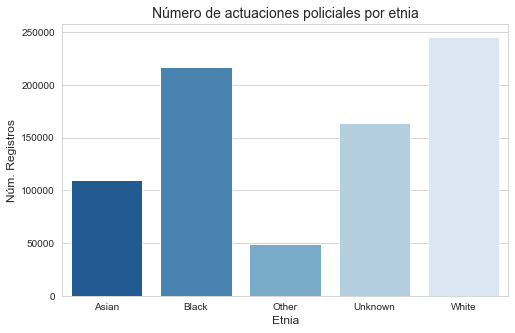

```python
# Gráfica con el número de actuaciones policiales por raza
plt.figure(figsize=(8, 5))
sns.set_style('whitegrid')
sns.countplot(x='Short-ethnicity', data=london_data, palette='Blues_r',
              order=sorted(london_data['Short-ethnicity'].unique()))
plt.title('Número de actuaciones policiales por etnia', fontsize=14)
plt.xlabel('Etnia', fontsize=12)
plt.ylabel('Núm. Registros', fontsize=12)
plt.show()
```

La relación entre registros positivos y negativos es bastante pareja en los grupos de asiáticos, negros y blancos. La mayor diferencia se observa en los registros con valor desconocido.

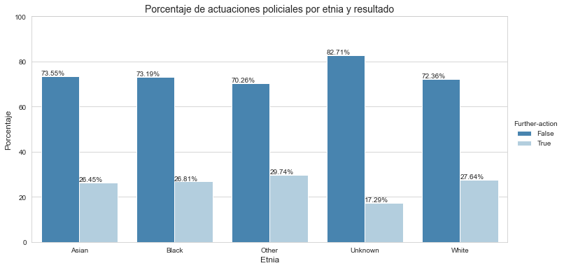

```python
# Porcentaje de registros por raza y resultado
percentage_plot(london_data, 'Short-ethnicity', 'Further-action',
                'Porcentaje de actuaciones policiales por etnia y resultado',
                'Etnia').show()
```

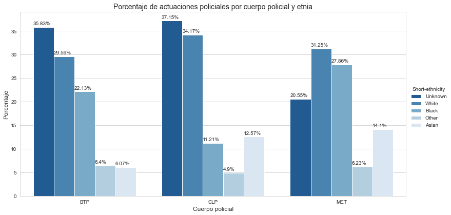

```python
# Porcentaje de registros por fuerza policial y etnia
percentage_plot(london_data, 'Source', 'Short-ethnicity',
                'Porcentaje de actuaciones policiales por cuerpo policial y etnia',
                'Cuerpo policial', height=5.5, aspect=2, limit_y=False).show()
```

Se muestra un resumen de actuaciones policiales por raza y distrito en un mapa de calor:

- Westminster y Lambeth son las ubicaciones donde más valores perdidos aparecen
- Tower Hamlets destaca en intervenciones sobre la población asiática
- Lambeth, Newham y Southwark sobresalen en las de población negra
- Las actuaciones sobre población blanca están más dispersas entre distritos, aunque destaca Westminster

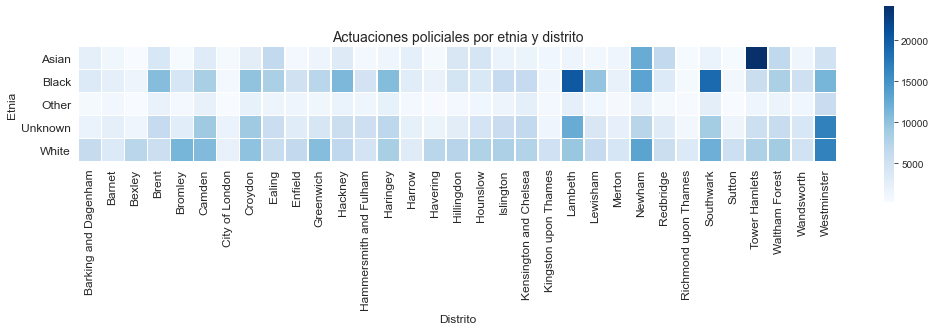

```python
# Se genera un mapa de calor por raza y distrito
cross_data = pd.crosstab(london_data['Short-ethnicity'],
                         london_data['Borough'],
                         values=london_data['Borough'],
                         aggfunc='count')

plt.figure(figsize=(17, 6))
sns.heatmap(cross_data, cmap="Blues", square=True, linewidths=.1, cbar=True, cbar_kws={"shrink": .60})
plt.tick_params(labelsize=12)
plt.title('Actuaciones policiales por etnia y distrito', fontsize=14)
plt.xlabel('Distrito', fontsize=12)
plt.ylabel('Etnia', fontsize=12)
plt.show()
```

#### 2.2.7 Variable *Officer-ethnicity*

Esta variable representa la raza o etnia que el agente de policía ha asignado al sospechoso.  
El número de categorías existente es mucho más limitado que el de la variable de etnia autoinformada y una de ellas, *Mixed*, presenta sólo 2 registros, que pasan a incluirse dentro de *Other*.

```python
# Información básica de la variable
print('Número de valores diferentes:', len(pd.unique(london_data['Officer-ethnicity'])))
print(london_data['Officer-ethnicity'].value_counts(dropna=False))
```

```
Número de valores diferentes: 6
Black    307525
White    295055
Asian    134285
Other     32871
NaN       15983
Mixed         2
Name: Officer-ethnicity, dtype: int64
```

```python
# Se asigna un valor por defecto a los registros con valor desconocido
london_data['Officer-ethnicity'] = london_data['Officer-ethnicity'].fillna('Unknown')

# Debido al bajo número de registros de 'Mixed' se absorben en la categoría de 'Other'
london_data['Officer-ethnicity'] = london_data['Officer-ethnicity'].apply(lambda x: 'Other' if x == 'Mixed' else x)
```

En la siguiente gráfica se aprecia que las personas de raza negra son las más paradas por la policía. Aunque la población blanca ha ido disminuyendo paulatinamente en Londres, no justifica la diferencia del número de registros policiales y más si se consideran conjuntamente los valores de la población negra y asiática.  
Esta circunstancia, además, no se observaba en la gráfica comparativa realizada para la variable analizada previamente, la de raza o etnia autoinformada, donde eran las personas blancas las más afectadas. Esta diferencia puede justificarse por el alto número de valores desconocidos existentes en la variable anterior.

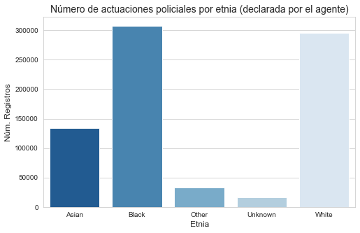

```python
# Gráfica con el número de actuaciones policiales por raza
plt.figure(figsize=(8, 5))
sns.set_style('whitegrid')
sns.countplot(x='Officer-ethnicity', data=london_data, palette='Blues_r',
              order=sorted(london_data['Officer-ethnicity'].unique()))
plt.title('Número de actuaciones policiales por etnia (declarada por el agente)', fontsize=14)
plt.xlabel('Etnia', fontsize=12)
plt.ylabel('Núm. Registros', fontsize=12)
plt.show()
```

El ratio de resultados positivos y negativos es bastante parejo en todos los grupos, aunque en el caso de la población blanca es aproximadamente 2 puntos superior a la negra o asiática.

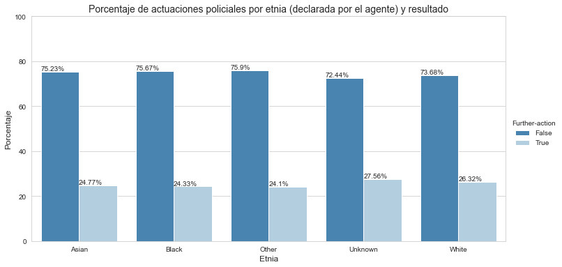

```python
# Porcentaje de registros por raza y resultado
percentage_plot(london_data, 'Officer-ethnicity', 'Further-action',
                'Porcentaje de actuaciones policiales por etnia (declarada por el agente) y resultado',
                'Etnia').show()
```

La gráfica de las mismas características mostrada para la etnia autoinformada, mostraba un elevado número de valores no conocidos, lo que alteraba los resultados. En este caso, al ser el número de registros desconocidos mucho menor, se puede considerar que la información obtenida es más fiable.  
Se observa que cambia el patrón visto en la variable anterior para la MET: en este caso, las personas de raza negra son interceptadas en mayor proporción que las blancas. Se produce el mismo efecto pero en sentido contrario para los otros dos cuerpos de policía, siendo los blancos los más afectados por este tipo de intervención. La diferencia entre ambas razas para CLP es especialmente acusada.

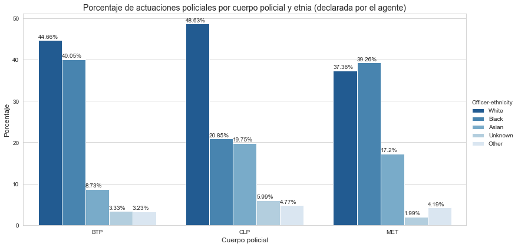

```python
# Porcentaje de registros por fuerza policial y etnia
percentage_plot(london_data, 'Source', 'Officer-ethnicity',
                'Porcentaje de actuaciones policiales por cuerpo policial y etnia (declarada por el agente)',
                'Cuerpo policial', height=5.5, aspect=2, limit_y=False).show()
```

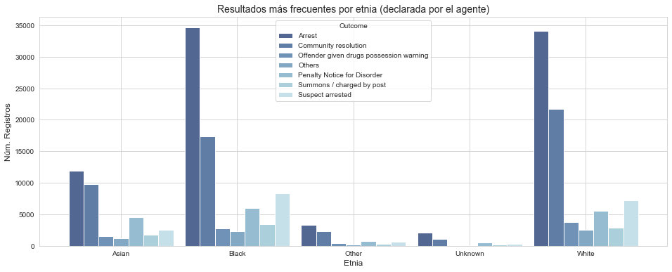

```python
# Se recogen los registros con resultado positivo y se agrupan en una misma categoría aquellos
# menos frecuentes
further_action_data = london_data[london_data['Further-action']].copy(deep=True)
further_action_data['Outcome'] = further_action_data['Outcome'].apply(lambda x: 'Others' if x in bottom_fa_list else x)

# Se muestran los registros positivos por etnia y tipo de resultado
cross_data = pd.crosstab(further_action_data['Officer-ethnicity'],
                         further_action_data['Outcome'],
                         values=further_action_data['Outcome'],
                         aggfunc='count')
cross_data.plot.bar(figsize=(16, 6), stacked=False, rot=0, width=0.9,
                    color=sns.cubehelix_palette(n_colors=7, start=0.05, rot=-.2, dark=.4, reverse=True))
plt.title('Resultados más frecuentes por etnia (declarada por el agente)', fontsize=14)
plt.xlabel('Etnia', fontsize=12)
plt.ylabel('Núm. Registros', fontsize=12)
plt.show()
```

No se observan diferencias reseñables entre el mapa de calor por distrito y raza de esta variable y la anterior.

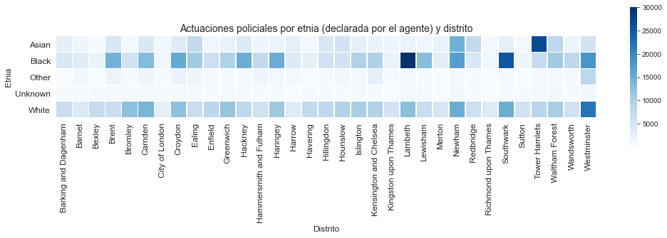

```python
# Se genera un mapa de calor por raza y distrito
cross_data = pd.crosstab(london_data['Officer-ethnicity'],
                         london_data['Borough'],
                         values=london_data['Borough'],
                         aggfunc='count')

plt.figure(figsize=(17, 6))
sns.heatmap(cross_data, cmap="Blues", square=True, linewidths=.1, cbar=True, cbar_kws={"shrink": .60})
plt.tick_params(labelsize=12)
plt.title('Actuaciones policiales por etnia (declarada por el agente) y distrito', fontsize=14)
plt.xlabel('Distrito', fontsize=12)
plt.ylabel('Etnia', fontsize=12)
plt.show()
```

En las gráficas anteriores los números aportados son en términos absolutos, sin considerar el tamaño de las diferentes poblaciones. Con el objetivo de incorporar esta información, se define la siguiente ratio:

$$ ratio\,por\,etnia = \frac{actuaciones\,por\,distrito\,y\,etnia}{población\,por\,distrito\,y\,etnia}\times100 \\ $$

Los datos correspondientes a la población de cada etnia existente en los distintos distritos londinenses se han extraído del censo de 2011.

```python
# Se genera un nuevo conjunto de datos para estudiar la ratio entre actuaciones policiales por zona
# y población de cada etnia

# Se descartan los registros cuya etnia es desconocida
eth_london_data = london_data[london_data['Officer-ethnicity']!='Unknown']
eth_london_data = eth_london_data.groupby(['Borough', 'Officer-ethnicity'], as_index=False)['Location'].count()

# Se reorganiza la información para mostrar las etnias como columnas del dataframe
eth_london_data = eth_london_data.pivot(index='Borough', columns='Officer-ethnicity').reset_index()
eth_london_data.columns = eth_london_data.columns.droplevel()
eth_london_data.rename(columns={'': 'Borough'}, inplace=True)
eth_london_data.head()
```

| Officer-ethnicity | Borough | Asian | Black | Other | White |
| --- | --- | --- | --- | --- | --- |
| 0 | Barking and Dagenham | 3055 | 4614 | 155 | 7077 |
| 1 | Barnet | 1533 | 3612 | 1012 | 4351 |
| 2 | Bexley | 435 | 2036 | 97 | 7611 |
| 3 | Brent | 4784 | 14502 | 1964 | 6756 |
| 4 | Bromley | 809 | 5814 | 233 | 12635 |

```python
# Se realiza un join entre el dataframe de datos de londres y el del censo para facilitar el cálculo
# posterior de la ratio
eth_london_data = eth_london_data.set_index('Borough').join(ethnic_data.set_index('Borough'), rsuffix='-pop')

# Se realiza el cálculo para cada columna asociada con una etnia
for col in ethnic_data.columns[1:len(ethnic_data.columns)-1]:
    eth_london_data[col] = eth_london_data.apply(lambda x: calculate_ratio(x[col], x[col+'-pop']), axis=1)

# Se seleccionan únicamente las columnas con la ratio generada
eth_london_subset = eth_london_data.iloc[:, 0:len(eth_london_data.columns)//2]
eth_london_subset.head(33)
```

| Borough | Asian | Black | Other | White |
| --- | --- | --- | --- | --- |
| Barking and Dagenham | 10.547940 | 12.266383 | 1.445761 | 6.515855 |
| Barnet | 2.342389 | 13.220116 | 2.918445 | 1.900481 |
| Bexley | 2.856955 | 10.589826 | 1.357593 | 3.997374 |
| Brent | 4.442381 | 25.184079 | 5.829623 | 6.018655 |
| Bromley | 5.077193 | 32.141080 | 1.728487 | 4.824545 |
| Camden | 12.829937 | 74.490426 | 6.706668 | 9.648774 |
| City of London | 115.531915 | 704.663212 | 57.336343 | 49.370581 |
| Croydon | 6.252891 | 21.734930 | 6.889128 | 6.165936 |
| Ealing | 8.203496 | 31.389061 | 4.498751 | 4.071909 |
| Enfield | 3.505775 | 12.657149 | 1.628355 | 4.420309 |
| Greenwich | 7.816817 | 21.499466 | 2.649126 | 7.224762 |
| Hackney | 16.514047 | 26.396702 | 2.224445 | 6.227673 |
| Hammersmith and Fulham | 8.747563 | 36.728784 | 7.684184 | 4.765988 |
| Haringey | 7.588744 | 31.827316 | 2.942417 | 7.335497 |
| Harrow | 2.991085 | 21.841464 | 4.618182 | 3.629262 |
| Havering | 7.829304 | 23.722115 | 1.566285 | 3.765322 |
| Hillingdon | 7.074390 | 30.890543 | 3.479684 | 4.822638 |
| Hounslow | 6.556567 | 33.630104 | 4.848610 | 7.127993 |
| Islington | 14.050727 | 36.647998 | 3.747476 | 7.237520 |
| Kensington and Chelsea | 13.854016 | 94.100323 | 13.964227 | 8.539992 |
| Kingston upon Thames | 5.522932 | 53.266332 | 5.016627 | 4.788285 |
| Lambeth | 10.021383 | 38.092941 | 2.975488 | 7.362602 |
| Lewisham | 4.933001 | 17.335798 | 1.321171 | 4.916054 |
| Merton | 5.544493 | 15.576642 | 1.536932 | 3.887031 |
| Newham | 11.145186 | 28.011209 | 2.230318 | 16.963580 |
| Redbridge | 6.815968 | 18.791182 | 1.930644 | 5.391472 |
| Richmond upon Thames | 5.641889 | 42.883686 | 2.013286 | 2.504785 |
| Southwark | 9.631976 | 32.910636 | 3.205411 | 9.557462 |
| Sutton | 3.622133 | 18.868549 | 1.239105 | 4.098169 |
| Tower Hamlets | 25.937897 | 41.259619 | 3.358647 | 7.670818 |
| Waltham Forest | 16.000754 | 25.253718 | 2.215203 | 7.612303 |
| Wandsworth | 5.385248 | 24.680368 | 2.196696 | 2.741130 |
| Westminster | 17.757390 | 118.922787 | 24.292432 | 16.077133 |

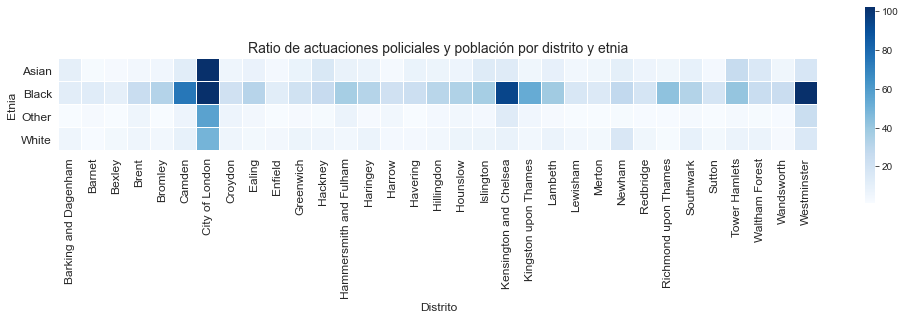

```python
# Se genera un mapa de calor con la información
plt.figure(figsize=(17, 6))
sns.heatmap(eth_london_subset.transpose(), robust=True, cmap="Blues", square=True, linewidths=.1,
            cbar=True, cbar_kws={"shrink": .60})
plt.tick_params(labelsize=12)
plt.title('Ratio de actuaciones policiales y población por distrito y etnia', fontsize=14)
plt.xlabel('Distrito', fontsize=12)
plt.ylabel('Etnia', fontsize=12)
plt.show()
```

El ratio en el distrito de la *city* es bastante más elevado en general que el obtenido para el resto de los distritos debido al alto número de actuaciones policiales en relación con su población.  
En cualquier caso, es fácil apreciar en la gráfica que el ratio correspondiente a la población negra es superior que el resto de razas en todos los distritos.  
En el caso de la población asiática, su ratio es mayor al de la población blanca en la mayoría de las zonas (26 frente a 7).

Se repite el ejercicio anterior pero calculando la ratio de los casos en los que la actuación policial ha tenido un resultado positivo.

```python
# Se genera un nuevo conjunto de datos para estudiar la ratio entre actuaciones policiales con resultado
# positivo por zona y población de cada etnia

# Se descartan los registros cuya etnia es desconocida y aquellos cuyo resultado no ha sido positivo
fa_eth_london_data = london_data[(london_data['Officer-ethnicity']!='Unknown') &
                                 (london_data['Further-action'])]

fa_eth_london_data = fa_eth_london_data.groupby(['Borough', 'Officer-ethnicity'], as_index=False)['Location'].count()

# Se reorganiza la información para mostrar las etnias como columnas del dataframe
fa_eth_london_data = fa_eth_london_data.pivot(index='Borough', columns='Officer-ethnicity').reset_index()
fa_eth_london_data.columns = fa_eth_london_data.columns.droplevel()
fa_eth_london_data.rename(columns={'': 'Borough'}, inplace=True)
fa_eth_london_data.head()
```

| Officer-ethnicity | Borough | Asian | Black | Other | White |
| --- | --- | --- | --- | --- | --- |
| 0 | Barking and Dagenham | 858 | 1362 | 29 | 2134 |
| 1 | Barnet | 459 | 964 | 247 | 1232 |
| 2 | Bexley | 138 | 676 | 26 | 2178 |
| 3 | Brent | 1231 | 3398 | 489 | 1831 |
| 4 | Bromley | 210 | 1536 | 49 | 3140 |

```python
# Se realiza un join entre el dataframe de datos de londres y el del censo para facilitar el cálculo
# posterior de la ratio
fa_eth_london_data = fa_eth_london_data.set_index('Borough').join(ethnic_data.set_index('Borough'), rsuffix='-pop')

# Se realiza el cálculo para cada columna asociada con una etnia
for col in ethnic_data.columns[1:len(ethnic_data.columns)-1]:
    fa_eth_london_data[col] = fa_eth_london_data.apply(lambda x: calculate_ratio(x[col], x[col+'-pop']), axis=1)

# Se seleccionan únicamente las columnas con la ratio generada
fa_eth_london_subset = fa_eth_london_data.iloc[:, 0:len(fa_eth_london_data.columns)//2]
fa_eth_london_subset.head(33)
```

| Borough | Asian | Black | Other | White |
| --- | --- | --- | --- | --- |
| Barking and Dagenham | 2.962400 | 3.620896 | 0.270497 | 1.964792 |
| Barnet | 0.701342 | 3.528292 | 0.712308 | 0.538128 |
| Bexley | 0.906344 | 3.516072 | 0.363891 | 1.143908 |
| Brent | 1.143096 | 5.900945 | 1.451469 | 1.631166 |
| Bromley | 1.317936 | 8.491348 | 0.363501 | 1.198977 |
| Camden | 2.931841 | 15.688697 | 1.741992 | 2.337166 |
| City of London | 30.638298 | 198.445596 | 14.221219 | 14.674944 |
| Croydon | 1.673719 | 6.112161 | 1.281620 | 1.597159 |
| Ealing | 2.138273 | 7.021349 | 1.169391 | 1.060593 |
| Enfield | 0.871378 | 3.531372 | 0.376481 | 1.107789 |
| Greenwich | 1.834667 | 5.398789 | 0.594702 | 1.826526 |
| Hackney | 3.830417 | 7.082212 | 0.593185 | 1.691623 |
| Hammersmith and Fulham | 2.570663 | 9.112139 | 1.936133 | 1.341561 |
| Haringey | 1.843877 | 7.506821 | 0.773395 | 1.792177 |
| Harrow | 0.828408 | 5.267251 | 1.109091 | 0.949370 |
| Havering | 2.684333 | 6.490427 | 0.500565 | 1.022449 |
| Hillingdon | 2.101628 | 7.078541 | 0.998091 | 1.369960 |
| Hounslow | 1.865260 | 8.089981 | 1.392686 | 1.875908 |
| Islington | 3.671867 | 8.850535 | 1.068597 | 1.809913 |
| Kensington and Chelsea | 3.974513 | 21.071632 | 3.907845 | 2.567638 |
| Kingston upon Thames | 1.738630 | 14.522613 | 1.311164 | 1.418410 |
| Lambeth | 2.613447 | 8.508126 | 0.770088 | 1.959309 |
| Lewisham | 1.541563 | 4.999397 | 0.311290 | 1.463826 |
| Merton | 1.433099 | 4.613139 | 0.405261 | 1.118796 |
| Newham | 2.686779 | 6.551735 | 0.603117 | 4.223926 |
| Redbridge | 1.780812 | 4.575775 | 0.466922 | 1.301502 |
| Richmond upon Thames | 1.860216 | 10.628019 | 0.551865 | 0.631151 |
| Southwark | 2.515380 | 7.657927 | 0.691075 | 2.376119 |
| Sutton | 0.887332 | 5.326423 | 0.294025 | 1.042259 |
| Tower Hamlets | 5.571588 | 10.817006 | 0.994011 | 2.106037 |
| Waltham Forest | 2.896201 | 5.097060 | 0.419766 | 1.830687 |
| Wandsworth | 1.424125 | 6.386665 | 0.530868 | 0.748124 |
| Westminster | 4.468312 | 25.518767 | 5.144110 | 4.119338 |

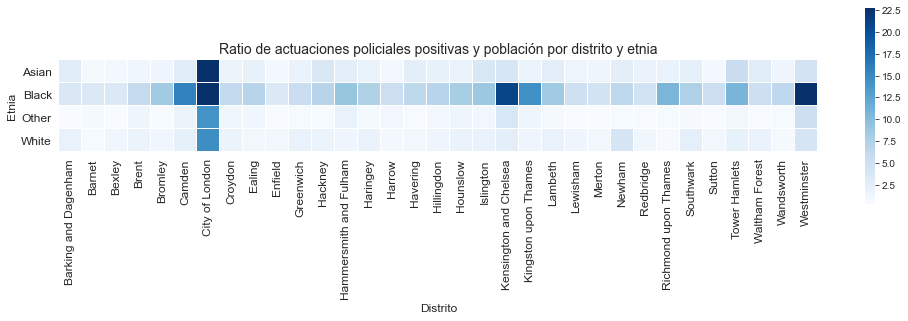

```python
# Se genera un mapa de calor con la información
plt.figure(figsize=(17, 6))
sns.heatmap(fa_eth_london_subset.transpose(), robust=True, cmap="Blues", square=True, linewidths=.1,
            cbar=True, cbar_kws={"shrink": .60})
plt.tick_params(labelsize=12)
plt.title('Ratio de actuaciones policiales positivas y población por distrito y etnia', fontsize=14)
plt.xlabel('Distrito', fontsize=12)
plt.ylabel('Etnia', fontsize=12)
plt.show()
```

No se aprecian diferencias destacables entre este mapa de calor, que representa las actuaciones con resultado positivo, y el anterior, que muestra el total de actuaciones policiales.  
Para confirmar lo que ya se había observado en gráficas anteriores, que en proporción las personas de raza negra no delinquen más, se calcula una nueva ratio que compara el número de actuaciones positivas y el número de actuaciones totales por etnia y distrito.

```python
# Selección de registros con el número de actuaciones positivas
fa_eth_london_data = london_data[(london_data['Officer-ethnicity']!='Unknown') &
                                 (london_data['Further-action'])]
fa_eth_london_data = fa_eth_london_data.groupby(['Borough', 'Officer-ethnicity'], as_index=False)['Location'].count()
fa_eth_london_data = fa_eth_london_data.pivot(index='Borough', columns='Officer-ethnicity').reset_index()
fa_eth_london_data.columns = fa_eth_london_data.columns.droplevel()
fa_eth_london_data.rename(columns={'': 'Borough'}, inplace=True)
fa_eth_london_data.head()
```

| Officer-ethnicity | Borough | Asian | Black | Other | White |
| --- | --- | --- | --- | --- | --- |
| 0 | Barking and Dagenham | 858 | 1362 | 29 | 2134 |
| 1 | Barnet | 459 | 964 | 247 | 1232 |
| 2 | Bexley | 138 | 676 | 26 | 2178 |
| 3 | Brent | 1231 | 3398 | 489 | 1831 |
| 4 | Bromley | 210 | 1536 | 49 | 3140 |

```python
# Selección de registros con el total de actuaciones policiales
all_eth_london_data = london_data[(london_data['Officer-ethnicity']!='Unknown')]
all_eth_london_data = all_eth_london_data.groupby(['Borough', 'Officer-ethnicity'], as_index=False)['Location'].count()
all_eth_london_data = all_eth_london_data.pivot(index='Borough', columns='Officer-ethnicity').reset_index()
all_eth_london_data.columns = all_eth_london_data.columns.droplevel()
all_eth_london_data.rename(columns={'': 'Borough'}, inplace=True)
all_eth_london_data.head()
```

| Officer-ethnicity | Borough | Asian | Black | Other | White |
| --- | --- | --- | --- | --- | --- |
| 0 | Barking and Dagenham | 3055 | 4614 | 155 | 7077 |
| 1 | Barnet | 1533 | 3612 | 1012 | 4351 |
| 2 | Bexley | 435 | 2036 | 97 | 7611 |
| 3 | Brent | 4784 | 14502 | 1964 | 6756 |
| 4 | Bromley | 809 | 5814 | 233 | 12635 |

```python
# Se calcula la ratio de actuaciones positivas frente a totales por cada etnia
comp_london_data = fa_eth_london_data.set_index('Borough').join(all_eth_london_data.set_index('Borough'), rsuffix='-all')
for col in ethnic_data.columns[1:len(ethnic_data.columns)-1]:
    comp_london_data[col] = comp_london_data.apply(lambda x: calculate_ratio(x[col], x[col+'-all']), axis=1)

# Se seleccionan las columnas con la ratio y se muestran
comp_london_data = comp_london_data.iloc[:, 0:len(comp_london_data.columns)//2]
comp_london_data.head(33)
```

| Officer-ethnicity Borough | Asian | Black | Other | White |
| --- | --- | --- | --- | --- |
| Barking and Dagenham | 28.085106 | 29.518856 | 18.709677 | 30.154020 |
| Barnet | 29.941292 | 26.688815 | 24.407115 | 28.315330 |
| Bexley | 31.724138 | 33.202358 | 26.804124 | 28.616476 |
| Brent | 25.731605 | 23.431251 | 24.898167 | 27.101835 |
| Bromley | 25.957973 | 26.418989 | 21.030043 | 24.851603 |
| Camden | 22.851562 | 21.061360 | 25.974026 | 24.222412 |
| City of London | 26.519337 | 28.161765 | 24.803150 | 29.724066 |
| Croydon | 26.767123 | 28.121376 | 18.603516 | 25.902944 |
| Ealing | 26.065386 | 22.368775 | 25.993691 | 26.046578 |
| Enfield | 24.855491 | 27.900214 | 23.120301 | 25.061339 |
| Greenwich | 23.470775 | 25.111272 | 22.448980 | 25.281465 |
| Hackney | 23.194903 | 26.829914 | 26.666667 | 27.163002 |
| Hammersmith and Fulham | 29.387187 | 24.809257 | 25.196335 | 28.148646 |
| Haringey | 24.297521 | 23.586097 | 26.284349 | 24.431569 |
| Harrow | 27.695914 | 24.115832 | 24.015748 | 26.158764 |
| Havering | 34.285714 | 27.360237 | 31.958763 | 27.154347 |
| Hillingdon | 29.707553 | 22.914912 | 28.683386 | 28.406863 |
| Hounslow | 28.448729 | 24.055771 | 28.723404 | 26.317484 |
| Islington | 26.132931 | 24.150120 | 28.515112 | 25.007364 |
| Kensington and Chelsea | 28.688525 | 22.392731 | 27.984685 | 30.066045 |
| Kingston upon Thames | 31.480195 | 27.264151 | 26.136364 | 29.622510 |
| Lambeth | 26.078710 | 22.335178 | 25.881057 | 26.611635 |
| Lewisham | 31.250000 | 28.838575 | 23.561644 | 29.776437 |
| Merton | 25.847243 | 29.615745 | 26.368159 | 28.782797 |
| Newham | 24.107082 | 23.389692 | 27.041742 | 24.899967 |
| Redbridge | 26.127062 | 24.350649 | 24.184783 | 24.140021 |
| Richmond upon Thames | 32.971506 | 24.783362 | 27.411168 | 25.197824 |
| Southwark | 26.114890 | 23.268851 | 21.559633 | 24.861399 |
| Sutton | 24.497487 | 28.229106 | 23.728814 | 25.432300 |
| Tower Hamlets | 21.480493 | 26.216931 | 29.595588 | 27.455181 |
| Waltham Forest | 18.100401 | 20.183404 | 18.949343 | 24.049056 |
| Wandsworth | 26.444929 | 25.877511 | 24.166667 | 27.292540 |
| Westminster | 25.163111 | 21.458265 | 21.175772 | 25.622341 |

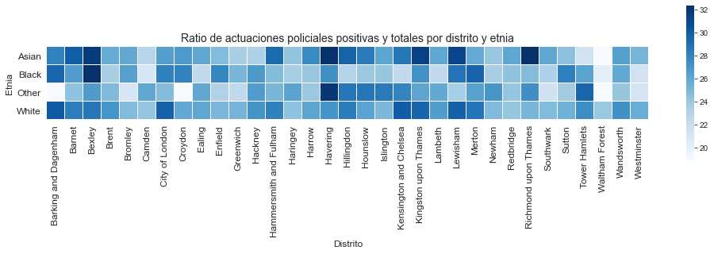

```python
# Se genera un mapa de calor con la información
plt.figure(figsize=(17, 6))
sns.heatmap(comp_london_data.transpose(), robust=True, cmap="Blues", square=True, linewidths=.1,
            cbar=True, cbar_kws={"shrink": .60})
plt.tick_params(labelsize=12)
plt.title('Ratio de actuaciones policiales positivas y totales por distrito y etnia', fontsize=14)
plt.xlabel('Distrito', fontsize=12)
plt.ylabel('Etnia', fontsize=12)
plt.show()
```

Con este ratio ya no se observa el efecto de las gráficas anteriores: si se compara el número de actuaciones positivas frente al número total, las personas de raza negra no sobresalen del resto. Las ratios más elevadas se distribuyen en diversas razas a lo largo de los distintos distritos.

En cuanto a la equiparación del número de registros según la raza declarada por el agente y la informada por el sospechoso, cuyo mapa de calor se muestra a continuación, se aprecia que los valores desconocidos de la autoinformada afectan a todas las etnias. Además, como era de esperar, hay una fuerte correlación entre las razas asiática, negra y blanca reportadas por la persona y por la policía.

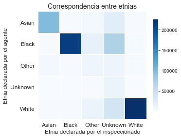

```python
# Se genera un mapa de calor para contrastar la etnia indicada por el agente de la declarada por
# la persona a inspeccionar
cross_data = pd.crosstab(london_data['Officer-ethnicity'],
                         london_data['Short-ethnicity'],
                         values=london_data['Short-ethnicity'],
                         aggfunc='count')

plt.figure(figsize=(5, 5))
sns.heatmap(cross_data, cmap="Blues", robust=True, square=True, linewidths=.1, cbar=True, cbar_kws={"shrink": .70})
plt.tick_params(labelsize=12)
plt.title('Correspondencia entre etnias', fontsize=14)
plt.yticks(rotation=0)
plt.xlabel('Etnia declarada por el inspeccionado', fontsize=12)
plt.ylabel('Etnia declarada por el agente', fontsize=12)
plt.show()
```

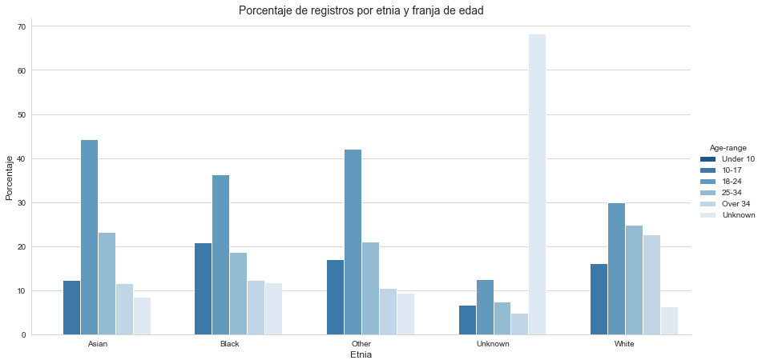

```python
# Porcentaje de registros totales por raza y franja de edad
percentage_plot(london_data, 'Officer-ethnicity', 'Age-range',
                'Porcentaje de registros por etnia y franja de edad',
                'Etnia', height=6, aspect=2, limit_y=False, show_percentage=False).show()
```

En el siguiente gráfico se pone de manifiesto que en la franja de 10-17 años y 18-24 predominan las actuaciones sobre personas negras, mientras que en las de 25-34 y mayores de 34 son las dirigidas a personas blancas.

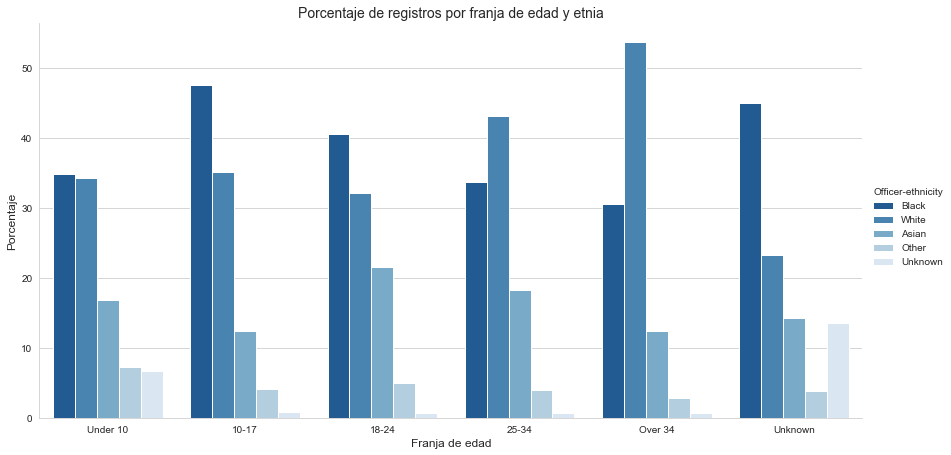

```python
# Porcentaje de registros totales por franja de edad y raza
percentage_plot(london_data, 'Age-range', 'Officer-ethnicity',
                'Porcentaje de registros por franja de edad y etnia',
                'Franja de edad', height=6, aspect=2, limit_y=False, show_percentage=False).show()
```

Revisando el porcentaje de tipos de actuación por etnia, se encuentra que la mayoría de los valores no conocidos están relacionados con las búsquedas en vehículos. Es probable que en estos casos los agentes se centren en informar datos correspondientes al vehículo (de los que no nos llega información) más que a sus ocupantes, siendo la policía metropolitana la que incurre más en este tipo de comportamiento.  
En los registros de vehículo y persona se observa que la proporción de gente negra es claramente superior al resto.

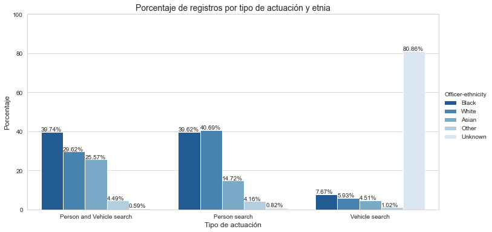

```python
# Porcentaje de registros totales por tipo de actuación y raza
percentage_plot(london_data, 'Type', 'Officer-ethnicity', 'Porcentaje de registros por tipo de actuación y etnia',
                'Tipo de actuación').show()
```

```python
# La práctica totalidad de registros de vehículos sin etnia informada tienen su origen en la MET
num_total = london_data[(london_data['Type']=='Vehicle search') &
                        (london_data['Officer-ethnicity']=='Unknown')].shape[0]
num_btp = london_data[(london_data['Type']=='Vehicle search') &
                      (london_data['Officer-ethnicity']=='Unknown') &
                      (london_data['Source']=='BTP')].shape[0]
num_clp = london_data[(london_data['Type']=='Vehicle search') &
                      (london_data['Officer-ethnicity']=='Unknown') &
                      (london_data['Source']=='CLP')].shape[0]
num_met = london_data[(london_data['Type']=='Vehicle search') &
                      (london_data['Officer-ethnicity']=='Unknown') &
                      (london_data['Source']=='MET')].shape[0]

print('Número total de registros de vehículo sin etnia informada:', num_total)
print('Porcentaje de registro de vehículos sin etnia informada (BTP):', '{:.2f}'.format(num_btp*100/num_total))
print('Porcentaje de registro de vehículos sin etnia informada (CLP):', '{:.2f}'.format(num_clp*100/num_total))
print('Porcentaje de registro de vehículos sin etnia informada (MET):', '{:.2f}'.format(num_met*100/num_total))
```

```
Número total de registros de vehículo sin etnia informada: 10042
Porcentaje de registro de vehículos sin etnia informada (BTP): 0.04
Porcentaje de registro de vehículos sin etnia informada (CLP): 0.00
Porcentaje de registro de vehículos sin etnia informada (MET): 99.96
```

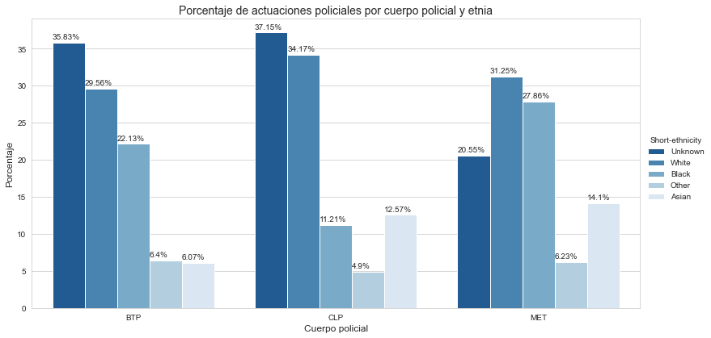

```python
# Porcentaje de registros por fuerza policial y etnia
percentage_plot(london_data, 'Source', 'Short-ethnicity',
                'Porcentaje de actuaciones policiales por cuerpo policial y etnia',
                'Cuerpo policial', height=5.5, aspect=2, limit_y=False).show()
```

#### 2.2.8 Variable *Date*

En esta variable queda registrado el momento en el que el agente informa que ha tenido lugar una intervención de *stop and search*, indicando además de la fecha, la hora y minutos.

```python
# Información básica de la variable
print('Número de valores diferentes:', len(pd.unique(london_data['Date'])))
print('Número de valores perdidos:', london_data['Date'].isnull().sum())

# Se crean varias variables nuevas para estudiar el comportamiento de la variable según el día del mes,
# la hora o el día de la semana
london_data['Day'] = london_data['Date'].dt.day
london_data['Hour'] = london_data['Date'].dt.hour
london_data['Day-of-week'] = london_data['Date'].dt.day_name()
```

```
Número de valores diferentes: 400591
Número de valores perdidos: 0
```

El viernes es el día que mas intervenciones acumula, probablemente porque se produce mayor movimiento de gente en las calles y zonas de ocio con el comienzo del fin de semana.

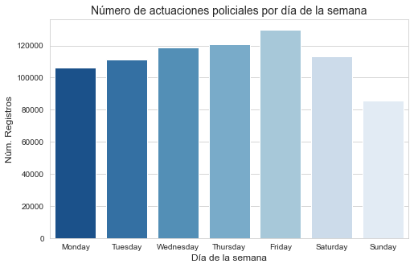

```python
# Ordenación del eje X
dow_order = ['Monday', 'Tuesday', 'Wednesday', 'Thursday', 'Friday', 'Saturday', 'Sunday']

# Gráfica con el número de actuaciones policiales por día de la semana
plt.figure(figsize=(8, 5))
sns.set_style('whitegrid')
sns.countplot(x='Day-of-week', data=london_data, palette='Blues_r', order=dow_order)
plt.title('Número de actuaciones policiales por día de la semana', fontsize=14)
plt.xlabel('Día de la semana', fontsize=12)
plt.ylabel('Núm. Registros', fontsize=12)
plt.show()
```

No obstante, la proporción entre registros con éxito y registros infructuosos es muy parecida en todos los días.

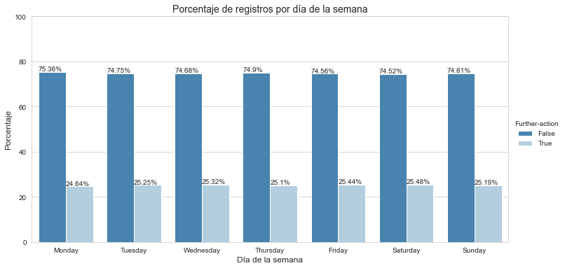

```python
# Porcentaje de registros por día de la semana
percentage_plot(london_data, 'Day-of-week', 'Further-action', 'Porcentaje de registros por día de la semana',
                'Día de la semana', order=dow_order).show()
```

A primera hora de la tarde, alrededor de las 15 horas, se produce un aumento de la actividad policial que dura hasta las 19 horas aproximadamente, pero no produce un aumento de registros con éxito en consonancia.

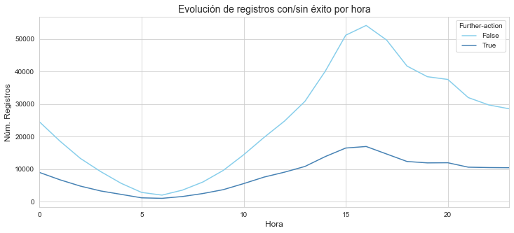

```python
# Evolución de registros por hora
# Se genera una tabla cruzada con el conteo de registros
cross_data = pd.crosstab(london_data['Hour'],
                         london_data['Further-action'],
                         values=london_data['Further-action'],
                         aggfunc='count')

# Se visualiza su evolución en una gráfica
cross_data.plot.line(figsize=(12, 5), color=['skyblue', 'steelblue'])
plt.title('Evolución de registros con/sin éxito por hora', fontsize=14)
plt.xlim([0, 23])
plt.xlabel('Hora', fontsize=12)
plt.ylabel('Núm. Registros', fontsize=12)
plt.show()
```

En la gráfica siguiente se realiza una comparativa de registros por día del mes y hora. Como se ya se apreciaba en la gráfica anterior, las horas de mayor actividad policial tienen lugar entre las 15 y las 19 horas. Aunque el patrón es bastante homogéneo, se observa que en los días cercanos a fin de mes, las intervenciones policiales aumentan de 12 a 14 respecto al resto de días.  
En cuanto a las horas y días en que tienen lugar más actuaciones con resultado positivo, no hay diferencias apreciables, coincidiendo con los momentos que concentran un mayor número de actuaciones policiales en general.

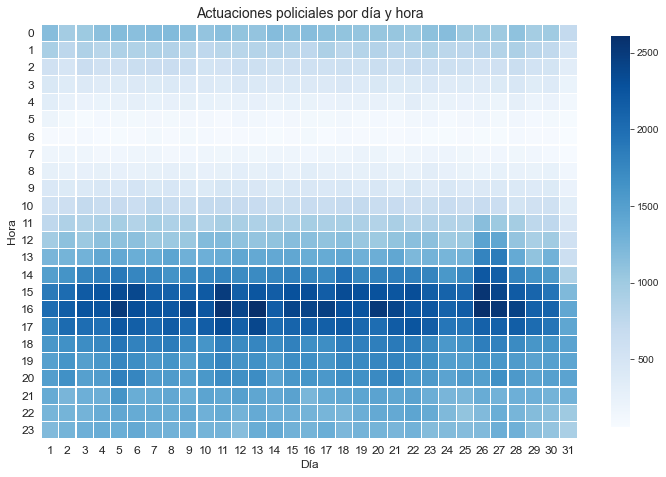

```python
# Se genera un mapa de calor por día y hora
cross_data = pd.crosstab(london_data['Hour'],
                         london_data['Day'],
                         values=london_data['Hour'],
                         aggfunc='count')

plt.figure(figsize=(12, 12))
sns.heatmap(cross_data, cmap="Blues", square=True, linewidths=.1, cbar_kws={"shrink": .60})
plt.tick_params(labelsize=12)
plt.yticks(rotation=0)
plt.title('Actuaciones policiales por día y hora', fontsize=14)
plt.xlabel('Día', fontsize=12)
plt.ylabel('Hora', fontsize=12)
plt.show()
```

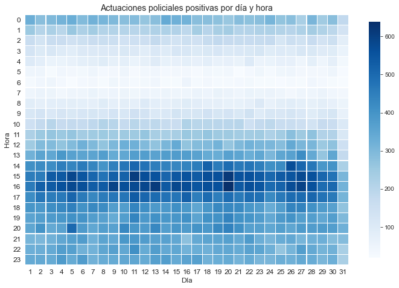

```python
# Selección de registros con resultado positivo en la actuación policial
further_action_data = london_data[london_data['Further-action']]

# Se genera un mapa de calor por día y hora
cross_data = pd.crosstab(further_action_data['Hour'],
                         further_action_data['Day'],
                         values=further_action_data['Hour'],
                         aggfunc='count')

plt.figure(figsize=(12, 12))
sns.heatmap(cross_data, cmap="Blues", square=True, linewidths=.1, cbar_kws={"shrink": .60})
plt.tick_params(labelsize=12)
plt.yticks(rotation=0)
plt.title('Actuaciones policiales positivas por día y hora', fontsize=14)
plt.xlabel('Día', fontsize=12)
plt.ylabel('Hora', fontsize=12)
plt.show()
```

#### 2.2.9 Variable *Legislation*

Este atributo recoge las leyes que justifican legalmente la intervención policial.

```python
# Información básica de la variable
print('Número de valores diferentes:', len(pd.unique(london_data['Legislation'])))
print(london_data['Legislation'].value_counts(dropna=False))
```

```
Número de valores diferentes: 11
Misuse of Drugs Act 1971 (section 23)                      479183
Police and Criminal Evidence Act 1984 (section 1)          275611
Criminal Justice and Public Order Act 1994 (section 60)     25648
Firearms Act 1968 (section 47)                               5249
NaN                                                            18
Psychoactive Substances Act 2016 (s36(2))                       4
Police and Criminal Evidence Act 1984 (section 6)               3
Aviation Security Act 1982 (section 27(1))                      2
Wildlife and Countryside Act 1981 (section 19)                  1
Deer Act 1991 (section 12)                                      1
Sporting Events Act 1985 (section 7)                            1
Name: Legislation, dtype: int64
```

```python
# Se agrupan los valores residuales en una misma categoría
london_data['Legislation'] = london_data['Legislation'].fillna('Other or unknown')
bottom_list = london_data['Legislation'].value_counts().nsmallest(6).keys()
london_data['Legislation'] = london_data['Legislation'].apply(lambda x: 'Other or unknown' if x in bottom_list else x)

# Se acorta el texto del resto de categorías
london_data['Legislation'] = london_data['Legislation'].apply(lambda x: x[0:x.find('(')-1] if x.find('(') >= 0 else x)
print(london_data['Legislation'].value_counts(dropna=False))
```

```
Misuse of Drugs Act 1971                      479183
Police and Criminal Evidence Act 1984         275611
Criminal Justice and Public Order Act 1994     25648
Firearms Act 1968                               5249
Other or unknown                                  30
Name: Legislation, dtype: int64
```

Predomina el uso de legislación relativa al uso de estupefacientes.

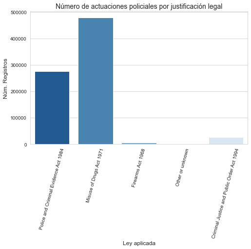

```python
# Gráfica con el número de actuaciones policiales por justificación legal
plt.figure(figsize=(8, 5))
sns.set_style('whitegrid')
sns.countplot(x='Legislation', data=london_data, palette='Blues_r')
plt.title('Número de actuaciones policiales por justificación legal', fontsize=14)
plt.xlabel('Ley aplicada', fontsize=12)
plt.ylabel('Núm. Registros', fontsize=12)
plt.xticks(rotation=75)
plt.show()
```

Las justificaciones legales con mayor proporción de actuaciones positivas son las relativas al uso de armas y drogas.

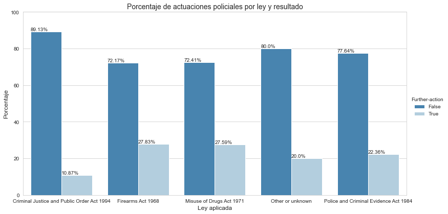

```python
# Porcentaje de registros por ley y resultado
percentage_plot(london_data, 'Legislation', 'Further-action',
                'Porcentaje de actuaciones policiales por ley y resultado',
                'Ley aplicada', height=5.5, aspect=2).show()
```

En el caso de las leyes que más se emplean para justificar el registro de sospechosos, destaca especialmente el empleo de las leyes relativas al orden público de 1994 y al uso de armas de fuego de 1968 en la población negra, con una proporción de casos muy diferenciado del resto de etnias.

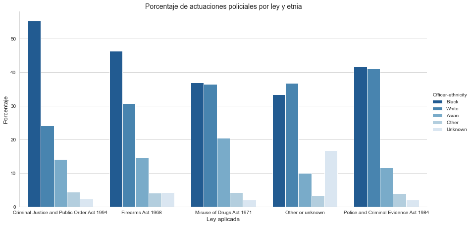

```python
ethnicity_order = ['Asian', 'Black', 'White', 'Other', 'Unknown']
# Porcentaje de registros por ley y raza
percentage_plot(london_data, 'Legislation', 'Officer-ethnicity',
                title='Porcentaje de actuaciones policiales por ley y etnia', x_label='Ley aplicada',
                palette='Blues_r', height=6, aspect=2, limit_y=False, show_percentage=False).show()
```

#### 2.2.10 Variable *Object*

Variable que recoge el tipo de objeto que la policía busca al realizar la intervención.

```python
# Información básica de la variable
print('Número de valores diferentes:', len(pd.unique(london_data['Object'])))
print(london_data['Object'].value_counts(dropna=False))
```

```
Número de valores diferentes: 14
Controlled drugs                              479107
Offensive weapons                             120332
Stolen goods                                   76843
Articles for use in criminal damage            39582
Evidence of offences under the Act             33236
Anything to threaten or harm anyone            25478
Firearms                                        5264
Fireworks                                       2615
NaN                                             1905
Article for use in theft                        1327
Goods on which duty has not been paid etc.        13
Psychoactive substances                           10
Crossbows                                          8
Evidence of wildlife offences                      1
Name: Object, dtype: int64
```

```python
# Se asigna un valor por defecto a los registros con valor desconocido
london_data['Object'] = london_data['Object'].fillna('Unknown')
```

Las drogas son el objeto más buscado por la policía, seguidas a mucha distancia por las armas y los objetos robados.

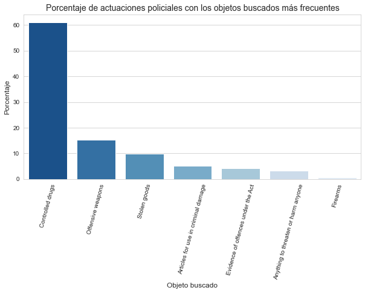

```python
# Resultados más frecuentes
top = ((london_data['Object']).value_counts(normalize=True, sort=True)*100).head(7)
top = top.to_frame().reset_index()
top.columns = ['Object', 'Percentage']

# Porcentaje de registros por resultados más frecuentes
plt.figure(figsize=(10, 5))
sns.set_style('whitegrid')
sns.barplot(x='Object', y='Percentage', data=top, palette='Blues_r')
plt.xlabel('Objeto buscado', size=12)
plt.ylabel('Porcentaje', size=12)
plt.title('Porcentaje de actuaciones policiales con los objetos buscados más frecuentes', size=14)
plt.xticks(rotation=75)
plt.show()
```

```python
# Se seleccionan las filas que pertenecen a los 5 objetos más buscados
top5_objects = top.nlargest(5, 'Percentage')['Object']
top5_objects_data = london_data.loc[london_data['Object'].isin(top5_objects)].copy(deep=True)
```

En cuanto a los objetos que se buscan en relación a la etnia del sospechoso, para los bienes robados y el concepto algo genérico de "evidencias" destaca la población blanca. En el caso de búsqueda de armas, son las personas negras las que predominan.

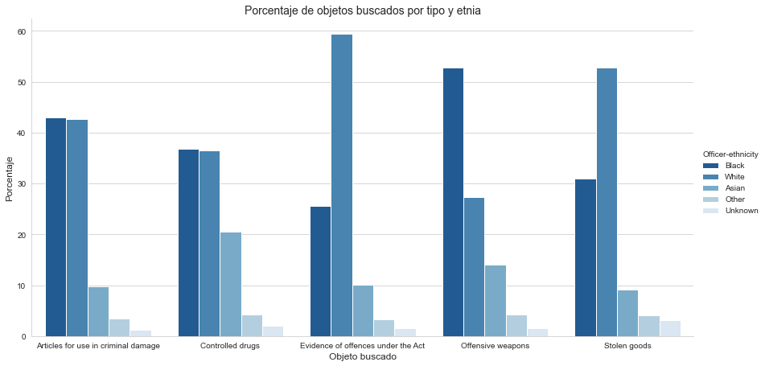

```python
# Porcentaje de objetos más buscados por tipo y etnia
percentage_plot(top5_objects_data, 'Object', 'Officer-ethnicity',
                'Porcentaje de objetos buscados por tipo y etnia',
                'Objeto buscado', palette='Blues_r', height=6, aspect=2, limit_y=False, show_percentage=False).show()
```

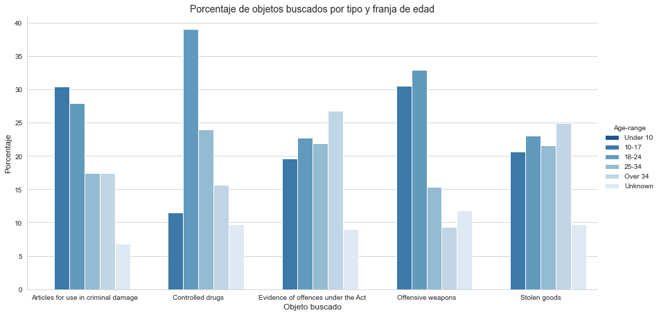

```python
# Porcentaje de objetos más buscados por tipo y franja de edad
percentage_plot(top5_objects_data, 'Object', 'Age-range',
                'Porcentaje de objetos buscados por tipo y franja de edad',
                'Objeto buscado', palette='Blues_r', height=6, aspect=2, limit_y=False, show_percentage=False).show()
```

#### 2.2.11 Variable *Outcome-object*

Esta variable indica si el resultado de la acción policial está vinculado al objeto que se buscaba o no.

```python
# Información básica de la variable
print('Número de valores diferentes:', len(pd.unique(london_data['Outcome-object'])))
print(london_data['Outcome-object'].value_counts(dropna=False))
```

```
Número de valores diferentes: 3
NaN      768110
False      8848
True       8763
Name: Outcome-object, dtype: Int64
```

El número de valores perdido es muy elevado, debiéndose a que la policía metropolitana no informa este campo en sus registros.

```python
print("Valores perdidos (BTP):", london_data[london_data['Source']=='MET']['Outcome-object'].isnull().sum())
print("Valores perdidos (CLP):", london_data[london_data['Source']=='CLP']['Outcome-object'].isnull().sum())
print("Valores perdidos (MET):", london_data[london_data['Source']=='BTP']['Outcome-object'].isnull().sum())
```

[output not shown]

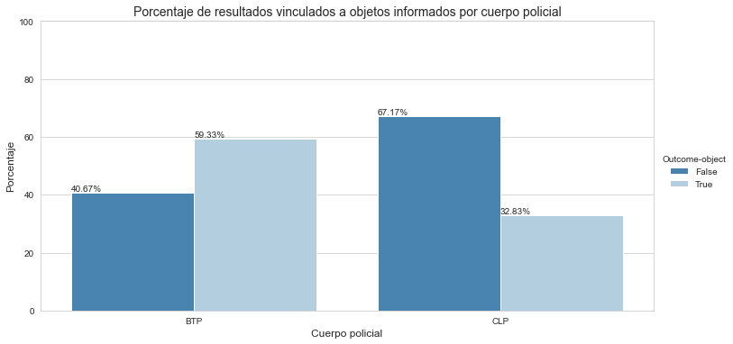

```python
# Porcentaje de registros con resultado vinculado al objeto por cuerpo policial
percentage_plot(top5_objects_data, 'Source', 'Outcome-object',
                'Porcentaje de resultados vinculados a objetos informados por cuerpo policial',
                'Cuerpo policial').show()
```

Los resultados están bastante nivelados a excepción de la opción "evidencia de delitos tipificados en la ley" que, al ser muy genérica, puede englobar casuísticas muy variadas y que en un porcentaje muy elevado no está vinculada al resultado de la intervención policial.  
En la correspondiente a armas ofensivas predominan los hallazgos positivos con casi un 60% de los resultados.

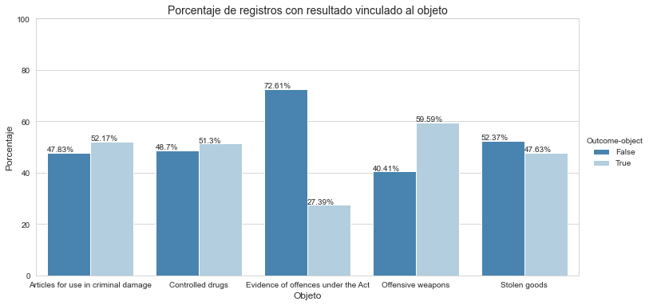

```python
# Porcentaje de registros con resultado vinculado al objeto según su tipo
percentage_plot(top5_objects_data, 'Object', 'Outcome-object',
                'Porcentaje de registros con resultado vinculado al objeto', 'Objeto').show()
```

Debido al alto porcentaje de valores perdidos se decide descartar esta variable para su uso posterior.

```python
# Se elimina la variable
london_data = london_data.drop('Outcome-object', axis=1)
```

#### 2.2.12 Variable *More-JOG*

Este atributo hace referencia a aquellos registros llevados a cabo por la policía que son más exhaustivos que un cacheo superficial (estos últimos denominados *JOG* en Reino Unido). Se trata de una variable booleana que vale True si se trata de un registro exhaustivo y False si es un cacheo.

```python
# Información básica de la variable
print('Número de valores diferentes:', len(pd.unique(london_data['More-JOG'])))
print(london_data['More-JOG'].value_counts(dropna=False))
print(london_data['More-JOG'].value_counts(dropna=False, normalize=True))
```

```
Número de valores diferentes: 3
NaN      768063
False     17364
True        294
Name: More-JOG, dtype: Int64
NaN      0.977526
False    0.022099
True     0.000374
Name: More-JOG, dtype: Float64
```

Aunque el número de valores perdidos es muy elevado y por tanto las conclusiones halladas no pueden considerarse concluyentes, se procede a realizar un pequeño análisis de la información disponible.

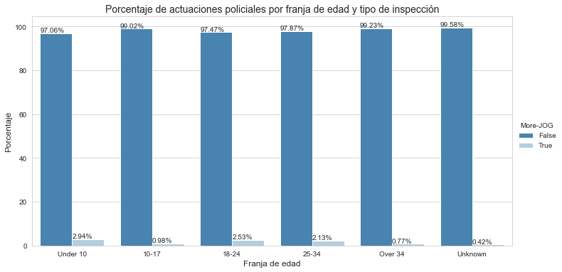

```python
# Porcentaje de registros por franja de edad y tipo de inspección realizada
percentage_plot(london_data, 'Age-range', 'More-JOG',
                'Porcentaje de actuaciones policiales por franja de edad y tipo de inspección',
                'Franja de edad', limit_y=False).show()
```

Sorprende que el mayor porcentaje de registros exhaustivos se produzca en los menores de 10 años, aunque muy probablemente esté distorsionado, como ya se comentaba en casos previos, por el bajo número de observaciones de esta franja de edad.

En cuanto a la etnia, se aprecia que la proporción de registros exhaustivos es mayor en las personas asiáticas, seguidas de las negras.

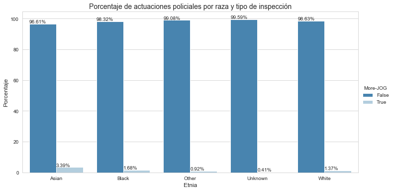

```python
# Porcentaje de registros por etnia y tipo de inspección realizada
percentage_plot(london_data, 'Officer-ethnicity', 'More-JOG',
                'Porcentaje de actuaciones policiales por raza y tipo de inspección',
                'Etnia', limit_y=False).show()
```

Dentro del tipo de inspección, la raza con mayor proporción de cacheos superficiales es la blanca, con una diferencia de 12 puntos sobre la siguiente.

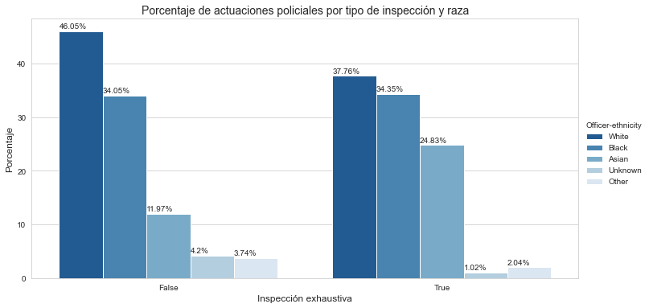

```python
# Porcentaje de registros por tipo de inspección y raza
percentage_plot(london_data, 'More-JOG', 'Officer-ethnicity',
                'Porcentaje de actuaciones policiales por tipo de inspección y raza',
                'Inspección exhaustiva', limit_y=False).show()
```

En cualquier caso, el número de valores perdidos es tan elevado para esta variable que las observaciones realizadas no pueden considerarse representativas. Se procede por tanto a descartar este atributo para su uso en el modelo posterior.

```python
# Se elimina la variable del dataset
london_data = london_data.drop('More-JOG', axis=1)
```

Se finaliza el análisis exploratorio guardando en fichero el conjunto de datos para su uso en la construcción de un modelo de predicción del resultado de actuaciones policiales.

```python
# Se guarda en fichero el dataset con las modificaciones realizadas
london_data.to_csv('./datasets/preproc-stop-and-search.csv', index=False, float_format='%f')
```